# Лабораторная работа 3: Перенос знаний с использованием PyTorch

## Цели работы

**Цель данной работы** — изучить и реализовать метод переноса знаний (transfer learning) для глубоких нейронных сетех для решения задачи классификации отходов на основе набора данных [Garbage Classification](https://www.kaggle.com/datasets/asdasdasasdas/garbage-classification). Предлагается применение переноса знаний к известным моделям глубокого обучения, обученным на наборе данных ImageNet.

## Задачи работы

Выполнение лабораторной работы предполагает решение следующих задач:

1. Загрузить набор данных Garbage Classification и выполнить предобработку данных, если это необходимо.
2. Выбрать 4 архитектуры нейронных сетей, для которых в открытом доступе существуют веса, настроенные на наборе данных ImageNet.
3. Модифицировать выбранные архитектуры нейронных сетей для работы с набором данных Garbage Classification. Выбрать гиперпараметры обучения и функцию ошибки.
4. Обучить модели со случайными весами на наборе данных Garbage Classification.
5. Обучить модель с весами, предварительно обученными на наборе данных ImageNet, на том же наборе данных Garbage Classification.
6. Сравнить результаты обученных моделей по метрикам точности.

## Требования к результатам выполнения работы

1. **Структура и содержимое Jupyter Notebook**:
   - Необходимо обеспечить демонстрацию избранных изображений и меток классов для подтверждения корректности загрузки и совпадения размерностей.
   - Загрузить и обучить 4 нейронные сети (можно использовать `torchvision`). Для каждой модели провести 2 эксперимента: первый — обучить всю модель со случайными весами, второй — реализовать перенос знаний, используя веса, обученные на ImageNet (выбрать любую модель, подходящую для переноса знаний). В этом случае можно обучать только классификатор; всю модель; используя предобученные веса, несколько последних слоев и т.д. Любой разумный вариант с использованием предобученных весов.
   - Построить график Macro F1-score от количества эпох для всех моделей на валидационных данных. Построить сравнительную столбчатую диаграмму точностей: модель и тип эксперимента (с кратким указанием параметров) по горизонтали, Macro F1-score на тестовых данных по вертикали.
2. **Проверка корректности**:
   - Разделите датасет на тренировочную, валидационную и тестовую выборки самостоятельно в соотношении 70/15/15.
   - Для оценки качества следует использовать **Macro F1-score**, поскольку датасет не сбалансирован.
3. **Архитектуры**:
   - Можно использовать любые сверточные архитектуры или архитектуры на базе механизма внимания (transformer, ViT и т.д.).
   - Хорошее понимание работы выбранных архитектур напрямую влияет на количество баллов за "знание". Будьте готовы кратко рассказать о особенностях выбранных или одной из выбранных архитектур при очной сдаче лабораторной работы.
   - Не бойтесь выбирать сложные архитектуры — чем сложнее архитектура, тем больше в ней интересного.

```python
import torch
import torch.nn as nn
import torchvision.transforms as transforms
from torchvision import datasets, models
from torch.utils.data import DataLoader
import matplotlib.pyplot as plt
import torch.optim as optim
from sklearn.metrics import confusion_matrix, ConfusionMatrixDisplay, f1_score
import numpy as np
```

```python
# Установка Seed для воспроизводимости
seed = 42
torch.manual_seed(seed)
torch.cuda.manual_seed(seed)
torch.cuda.manual_seed_all(seed)
np.random.seed(seed)
```

```python
import kagglehub

# Download latest version
path = kagglehub.dataset_download("asdasdasasdas/garbage-classification")

print("Path to dataset files:", path)
```

```
Using Colab cache for faster access to the 'garbage-classification' dataset.
Path to dataset files: /kaggle/input/garbage-classification
```

```python
data_dir = "/kaggle/input/garbage-classification/Garbage classification/Garbage classification"

transform = transforms.Compose([
    transforms.Resize((224, 224)),
    transforms.ToTensor()
])

dataset = datasets.ImageFolder(data_dir, transform=transform)

train_size = int(0.7 * len(dataset))
val_size = len(dataset) - train_size

train_ds, val_ds = torch.utils.data.random_split(dataset, [train_size, val_size])

val_size = int(0.5 * len(val_ds))
test_size = len(val_ds) - val_size

val_ds, test_ds = torch.utils.data.random_split(val_ds, [val_size, test_size])

train_loader = DataLoader(train_ds, batch_size=32, shuffle=True)
val_loader = DataLoader(val_ds, batch_size=32)
test_loader = DataLoader(test_ds, batch_size=32)

classes = dataset.classes
```

```python
classes
```

```
['cardboard', 'glass', 'metal', 'paper', 'plastic', 'trash']
```

```python
image, label = next(iter(train_loader))
```

```python
image.shape
```

```
torch.Size([32, 3, 224, 224])
```

```python
def image_show(img):
  plt.imshow(np.transpose(img.numpy(), (1, 2, 0)))
  plt.show()
```

[figure not shown]

```
glass
```

```python
image_show(image[2])
print(classes[label[2]])
```

```python
def model_validate(model, loader, device=torch.device("cpu")):
    test_predicts = []
    test_labels = []

    model.eval()
    with torch.no_grad():
        for image, label in loader:
          image = image.to(device)
          label = label.to(device)
          output = model(image)
          predict = torch.argmax(output, dim=1)
          test_predicts.extend(predict.cpu().numpy())
          test_labels.extend(label.cpu().numpy())

    return f1_score(test_labels, test_predicts, average='macro')
```

```python
def train_model(model, optimizer, criterion, device=torch.device("cpu"), num_epoch=20):
    macro_f1_list = []

    for epoch in range(num_epoch):
        macro_f1_epoch = []
        loss_epoch = []
        val_predicts_epoch = []
        val_labels_epoch = []

        model.train()
        for image, label in train_loader:
            image = image.to(device)
            label = label.to(device)

            output = model(image)
            loss = criterion(output, label)
            loss_epoch.append(loss.item())

            optimizer.zero_grad()
            loss.backward()
            optimizer.step()

        macro_f1 = model_validate(model, val_loader, device=device)
        macro_f1_list.append(macro_f1)
        print(f'Epoch:{epoch}, Loss:{np.mean(loss_epoch):.4f}, Val macro F1: {macro_f1:.4f}')

    plt.figure(figsize=(10, 6))
    plt.plot(np.arange(num_epoch), macro_f1_list)
    plt.xlabel('Epoch', fontsize=20)
    plt.ylabel('Val macro F1', fontsize=20)
    plt.show()

    return model, macro_f1_list
```

```python
device = torch.device("cuda" if torch.cuda.is_available() else "cpu")
```

```python
device
```

```
device(type='cuda')
```

```python
criterion = nn.CrossEntropyLoss()
```

```python
class ResNet(nn.Module):
    def __init__(self, num_classes):
        super().__init__()
        self.model = models.resnet50(weights=None)
        in_features = self.model.fc.in_features
        self.model.fc = nn.Linear(in_features, num_classes)

    def forward(self, x):
        return self.model(x)
```

```python
model = ResNet(len(classes))
model.to(device)
optimizer = optim.Adam(model.parameters(), lr=0.0005)
```

```
Epoch:0, Loss:1.5666, Val macro F1: 0.3817
Epoch:1, Loss:1.1708, Val macro F1: 0.1182
Epoch:2, Loss:1.0611, Val macro F1: 0.3472
Epoch:3, Loss:0.9933, Val macro F1: 0.4093
Epoch:4, Loss:0.8893, Val macro F1: 0.4577
Epoch:5, Loss:0.8324, Val macro F1: 0.2589
Epoch:6, Loss:0.7953, Val macro F1: 0.3709
Epoch:7, Loss:0.7601, Val macro F1: 0.6694
Epoch:8, Loss:0.6968, Val macro F1: 0.2124
Epoch:9, Loss:0.7031, Val macro F1: 0.4630
Epoch:10, Loss:0.6043, Val macro F1: 0.2006
Epoch:11, Loss:0.5997, Val macro F1: 0.4321
Epoch:12, Loss:0.5672, Val macro F1: 0.3161
Epoch:13, Loss:0.4724, Val macro F1: 0.4070
Epoch:14, Loss:0.4372, Val macro F1: 0.4221
Epoch:15, Loss:0.4405, Val macro F1: 0.3054
Epoch:16, Loss:0.3941, Val macro F1: 0.4732
Epoch:17, Loss:0.3755, Val macro F1: 0.3278
Epoch:18, Loss:0.2996, Val macro F1: 0.5955
Epoch:19, Loss:0.3376, Val macro F1: 0.6633
Epoch:20, Loss:0.2362, Val macro F1: 0.6737
Epoch:21, Loss:0.2929, Val macro F1: 0.6076
Epoch:22, Loss:0.2537, Val macro F1: 0.5119
Epoch:23, Loss:0.3863, Val macro F1: 0.5216
Epoch:24, Loss:0.3713, Val macro F1: 0.6684
```

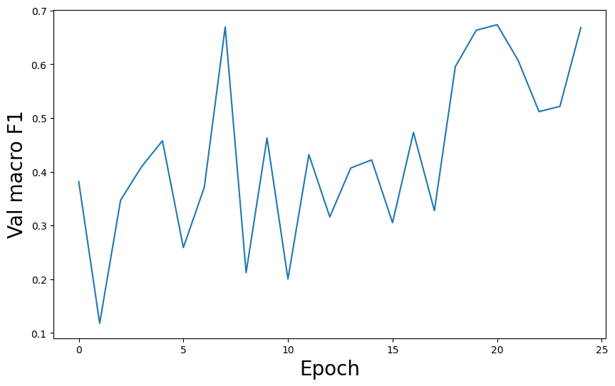

```python
trained_resnet, macro_f1_list_resnet = train_model(model, optimizer, criterion, device=device, num_epoch=25)
```

```python
class ResNetPreTrained(nn.Module):
    def __init__(self, num_classes):
        super().__init__()
        self.model = models.resnet50(weights=models.ResNet50_Weights.IMAGENET1K_V1)
        for param in self.model.parameters():
            param.requires_grad = False

        in_features = self.model.fc.in_features
        self.model.fc = nn.Linear(in_features, num_classes)

    def forward(self, x):
        return self.model(x)
```

```python
model = ResNetPreTrained(len(classes))
model.to(device)
optimizer = optim.Adam(model.model.fc.parameters(), lr=0.0005)
```

```
Downloading: "https://download.pytorch.org/models/resnet50-0676ba61.pth" to /root/.cache/torch/hub/checkpoints/resnet50-0676ba61.pth
```

```
Epoch:0, Loss:1.2696, Val macro F1: 0.5586
Epoch:1, Loss:0.8235, Val macro F1: 0.6570
Epoch:2, Loss:0.6773, Val macro F1: 0.6852
Epoch:3, Loss:0.5861, Val macro F1: 0.7193
Epoch:4, Loss:0.5237, Val macro F1: 0.6978
Epoch:5, Loss:0.5016, Val macro F1: 0.7528
Epoch:6, Loss:0.4777, Val macro F1: 0.7404
Epoch:7, Loss:0.4500, Val macro F1: 0.7329
Epoch:8, Loss:0.4211, Val macro F1: 0.7695
Epoch:9, Loss:0.4085, Val macro F1: 0.7685
Epoch:10, Loss:0.3808, Val macro F1: 0.7676
Epoch:11, Loss:0.3778, Val macro F1: 0.7803
Epoch:12, Loss:0.3543, Val macro F1: 0.7793
Epoch:13, Loss:0.3500, Val macro F1: 0.7892
Epoch:14, Loss:0.3485, Val macro F1: 0.7824
Epoch:15, Loss:0.3339, Val macro F1: 0.7889
Epoch:16, Loss:0.3251, Val macro F1: 0.7811
Epoch:17, Loss:0.3236, Val macro F1: 0.7764
Epoch:18, Loss:0.3002, Val macro F1: 0.7832
Epoch:19, Loss:0.3110, Val macro F1: 0.7980
Epoch:20, Loss:0.3036, Val macro F1: 0.7874
Epoch:21, Loss:0.2904, Val macro F1: 0.7708
Epoch:22, Loss:0.2937, Val macro F1: 0.7905
Epoch:23, Loss:0.2684, Val macro F1: 0.7821
Epoch:24, Loss:0.2785, Val macro F1: 0.7965
```

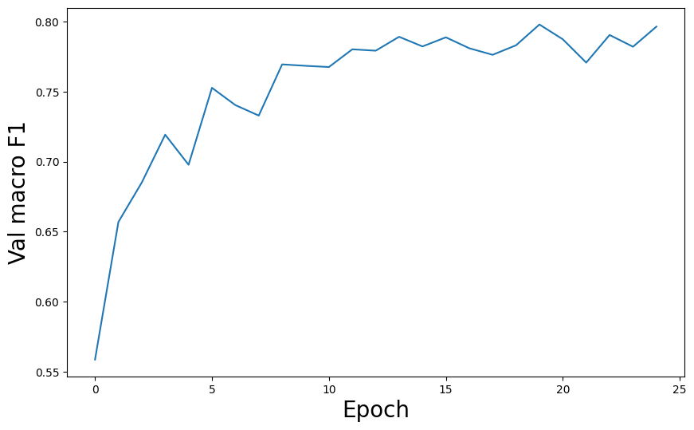

```python
trained_resnet_pretrain, macro_f1_list_resnet_pretrain = train_model(model, optimizer, criterion, device=device, num_epoch=25)
```

```python
models.mobilenet_v3_small(weights=None).classifier
```

```
Sequential(
  (0): Linear(in_features=576, out_features=1024, bias=True)
  (1): Hardswish()
  (2): Dropout(p=0.2, inplace=True)
  (3): Linear(in_features=1024, out_features=1000, bias=True)
)
```

```python
class MobileNet(nn.Module):
    def __init__(self, num_classes):
        super().__init__()
        self.model = models.mobilenet_v3_small(weights=None)
        in_features = self.model.classifier[3].in_features
        self.model.classifier[3] = nn.Linear(in_features, num_classes)

    def forward(self, x):
        return self.model(x)
```

```python
model = MobileNet(len(classes))
model.to(device)
optimizer = optim.Adam(model.parameters(), lr=0.0005)
```

```
Epoch:0, Loss:1.5178, Val macro F1: 0.0545
Epoch:1, Loss:1.1385, Val macro F1: 0.0545
Epoch:2, Loss:0.9428, Val macro F1: 0.0545
Epoch:3, Loss:0.7941, Val macro F1: 0.0545
Epoch:4, Loss:0.6253, Val macro F1: 0.0545
Epoch:5, Loss:0.5549, Val macro F1: 0.0545
Epoch:6, Loss:0.4891, Val macro F1: 0.0545
Epoch:7, Loss:0.3494, Val macro F1: 0.0545
Epoch:8, Loss:0.3188, Val macro F1: 0.0545
Epoch:9, Loss:0.3085, Val macro F1: 0.1697
Epoch:10, Loss:0.2547, Val macro F1: 0.2515
Epoch:11, Loss:0.1814, Val macro F1: 0.3354
Epoch:12, Loss:0.1715, Val macro F1: 0.4708
Epoch:13, Loss:0.1904, Val macro F1: 0.5288
Epoch:14, Loss:0.1690, Val macro F1: 0.5065
Epoch:15, Loss:0.1548, Val macro F1: 0.5193
Epoch:16, Loss:0.2167, Val macro F1: 0.4524
Epoch:17, Loss:0.1090, Val macro F1: 0.5490
Epoch:18, Loss:0.0882, Val macro F1: 0.5101
Epoch:19, Loss:0.0867, Val macro F1: 0.5574
Epoch:20, Loss:0.1464, Val macro F1: 0.5376
Epoch:21, Loss:0.1483, Val macro F1: 0.5373
Epoch:22, Loss:0.1070, Val macro F1: 0.4295
Epoch:23, Loss:0.0748, Val macro F1: 0.5649
Epoch:24, Loss:0.0449, Val macro F1: 0.6101
```

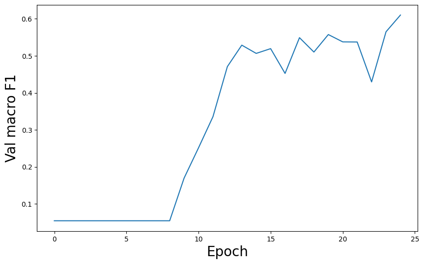

```python
trained_mobilenet, macro_f1_list_mobilenet = train_model(model, optimizer, criterion, device=device, num_epoch=25)
```

```python
class MobileNetPreTrained(nn.Module):
    def __init__(self, num_classes):
        super().__init__()
        self.model = models.mobilenet_v3_small(weights=models.MobileNet_V3_Small_Weights.IMAGENET1K_V1)
        for param in self.model.parameters():
            param.requires_grad = False

        in_features = self.model.classifier[3].in_features
        self.model.classifier[3] = nn.Linear(in_features, num_classes)

    def forward(self, x):
        return self.model(x)
```

```python
model = MobileNetPreTrained(len(classes))
model.to(device)
optimizer = optim.Adam(model.model.classifier[3].parameters(), lr=0.0005)
```

```
Downloading: "https://download.pytorch.org/models/mobilenet_v3_small-047dcff4.pth" to /root/.cache/torch/hub/checkpoints/mobilenet_v3_small-047dcff4.pth
```

```
Epoch:0, Loss:1.3875, Val macro F1: 0.5065
Epoch:1, Loss:0.9410, Val macro F1: 0.5417
Epoch:2, Loss:0.7812, Val macro F1: 0.6119
Epoch:3, Loss:0.6895, Val macro F1: 0.6588
Epoch:4, Loss:0.6087, Val macro F1: 0.6884
Epoch:5, Loss:0.5816, Val macro F1: 0.6829
Epoch:6, Loss:0.5287, Val macro F1: 0.7057
Epoch:7, Loss:0.5128, Val macro F1: 0.6968
Epoch:8, Loss:0.4854, Val macro F1: 0.7108
Epoch:9, Loss:0.4532, Val macro F1: 0.7415
Epoch:10, Loss:0.4412, Val macro F1: 0.7547
Epoch:11, Loss:0.4363, Val macro F1: 0.7588
Epoch:12, Loss:0.4124, Val macro F1: 0.7786
Epoch:13, Loss:0.3898, Val macro F1: 0.7769
Epoch:14, Loss:0.3901, Val macro F1: 0.7791
Epoch:15, Loss:0.3826, Val macro F1: 0.7822
Epoch:16, Loss:0.3662, Val macro F1: 0.7862
Epoch:17, Loss:0.3665, Val macro F1: 0.7874
Epoch:18, Loss:0.3375, Val macro F1: 0.7979
Epoch:19, Loss:0.3384, Val macro F1: 0.7932
Epoch:20, Loss:0.3244, Val macro F1: 0.7907
Epoch:21, Loss:0.3222, Val macro F1: 0.8028
Epoch:22, Loss:0.3107, Val macro F1: 0.7935
Epoch:23, Loss:0.3323, Val macro F1: 0.7901
Epoch:24, Loss:0.3032, Val macro F1: 0.7845
```

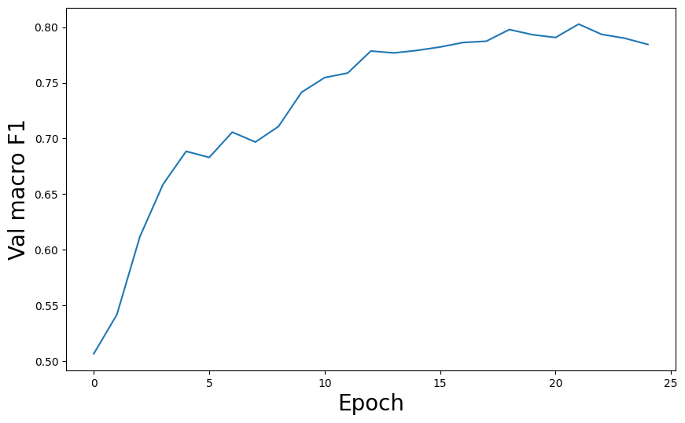

```python
trained_mobilenet_pretrain, macro_f1_list_mobilenet_pretrain = train_model(model, optimizer, criterion, device=device, num_epoch=25)
```

```python
models.alexnet(weights=None).classifier
```

```
Sequential(
  (0): Dropout(p=0.5, inplace=False)
  (1): Linear(in_features=9216, out_features=4096, bias=True)
  (2): ReLU(inplace=True)
  (3): Dropout(p=0.5, inplace=False)
  (4): Linear(in_features=4096, out_features=4096, bias=True)
  (5): ReLU(inplace=True)
  (6): Linear(in_features=4096, out_features=1000, bias=True)
)
```

```python
class AlexNet(nn.Module):
    def __init__(self, num_classes):
        super().__init__()
        self.model = models.alexnet(weights=None)
        in_features = self.model.classifier[6].in_features
        self.model.classifier[6] = nn.Linear(in_features, num_classes)

    def forward(self, x):
        return self.model(x)
```

```python
model = AlexNet(len(classes))
model.to(device)
optimizer = optim.Adam(model.parameters(), lr=0.0005)
```

```
Epoch:0, Loss:1.7337, Val macro F1: 0.0645
Epoch:1, Loss:1.7270, Val macro F1: 0.0645
Epoch:2, Loss:1.7287, Val macro F1: 0.0645
Epoch:3, Loss:1.7252, Val macro F1: 0.0545
Epoch:4, Loss:1.6814, Val macro F1: 0.0653
Epoch:5, Loss:1.6967, Val macro F1: 0.2851
Epoch:6, Loss:1.5934, Val macro F1: 0.2820
Epoch:7, Loss:1.5130, Val macro F1: 0.2230
Epoch:8, Loss:1.4945, Val macro F1: 0.2166
Epoch:9, Loss:1.4760, Val macro F1: 0.3536
Epoch:10, Loss:1.4062, Val macro F1: 0.3468
Epoch:11, Loss:1.4043, Val macro F1: 0.3363
Epoch:12, Loss:1.3411, Val macro F1: 0.3633
Epoch:13, Loss:1.2815, Val macro F1: 0.4109
Epoch:14, Loss:1.2661, Val macro F1: 0.3907
Epoch:15, Loss:1.1874, Val macro F1: 0.4122
Epoch:16, Loss:1.1450, Val macro F1: 0.4262
Epoch:17, Loss:1.0921, Val macro F1: 0.4633
Epoch:18, Loss:1.0317, Val macro F1: 0.4489
Epoch:19, Loss:0.9619, Val macro F1: 0.4803
Epoch:20, Loss:0.9001, Val macro F1: 0.5429
Epoch:21, Loss:0.8251, Val macro F1: 0.4862
Epoch:22, Loss:0.7766, Val macro F1: 0.5784
Epoch:23, Loss:0.7582, Val macro F1: 0.4861
Epoch:24, Loss:0.6643, Val macro F1: 0.5235
```

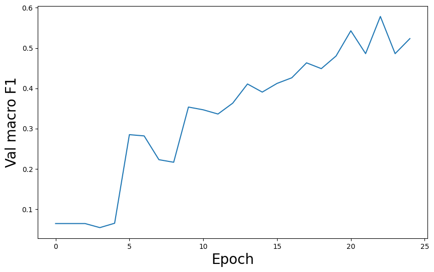

```python
trained_alexnet, macro_f1_list_alexnet = train_model(model, optimizer, criterion, device=device, num_epoch=25)
```

```python
class AlexNetPreTrained(nn.Module):
    def __init__(self, num_classes):
        super().__init__()
        self.model = models.alexnet(weights=models.AlexNet_Weights.IMAGENET1K_V1)
        for param in self.model.parameters():
            param.requires_grad = False

        in_features = self.model.classifier[6].in_features
        self.model.classifier[6] = nn.Linear(in_features, num_classes)

    def forward(self, x):
        return self.model(x)
```

```python
model = AlexNetPreTrained(len(classes))
model.to(device)
optimizer = optim.Adam(model.model.classifier[6].parameters(), lr=0.0005)
```

```
Downloading: "https://download.pytorch.org/models/alexnet-owt-7be5be79.pth" to /root/.cache/torch/hub/checkpoints/alexnet-owt-7be5be79.pth
```

```
Epoch:0, Loss:1.1787, Val macro F1: 0.5762
Epoch:1, Loss:0.8360, Val macro F1: 0.6340
Epoch:2, Loss:0.7336, Val macro F1: 0.6604
Epoch:3, Loss:0.6922, Val macro F1: 0.6058
Epoch:4, Loss:0.6241, Val macro F1: 0.6822
Epoch:5, Loss:0.5873, Val macro F1: 0.6609
Epoch:6, Loss:0.5849, Val macro F1: 0.7150
Epoch:7, Loss:0.5335, Val macro F1: 0.7069
Epoch:8, Loss:0.5128, Val macro F1: 0.7013
Epoch:9, Loss:0.4999, Val macro F1: 0.6919
Epoch:10, Loss:0.4890, Val macro F1: 0.7122
Epoch:11, Loss:0.4871, Val macro F1: 0.7080
Epoch:12, Loss:0.4695, Val macro F1: 0.6763
Epoch:13, Loss:0.4473, Val macro F1: 0.7068
Epoch:14, Loss:0.4335, Val macro F1: 0.7185
Epoch:15, Loss:0.4121, Val macro F1: 0.7141
Epoch:16, Loss:0.3951, Val macro F1: 0.7190
Epoch:17, Loss:0.3951, Val macro F1: 0.6994
Epoch:18, Loss:0.4075, Val macro F1: 0.7361
Epoch:19, Loss:0.3839, Val macro F1: 0.7408
Epoch:20, Loss:0.3724, Val macro F1: 0.7228
Epoch:21, Loss:0.3716, Val macro F1: 0.7381
Epoch:22, Loss:0.3618, Val macro F1: 0.7580
Epoch:23, Loss:0.3352, Val macro F1: 0.7005
Epoch:24, Loss:0.3455, Val macro F1: 0.7559
```

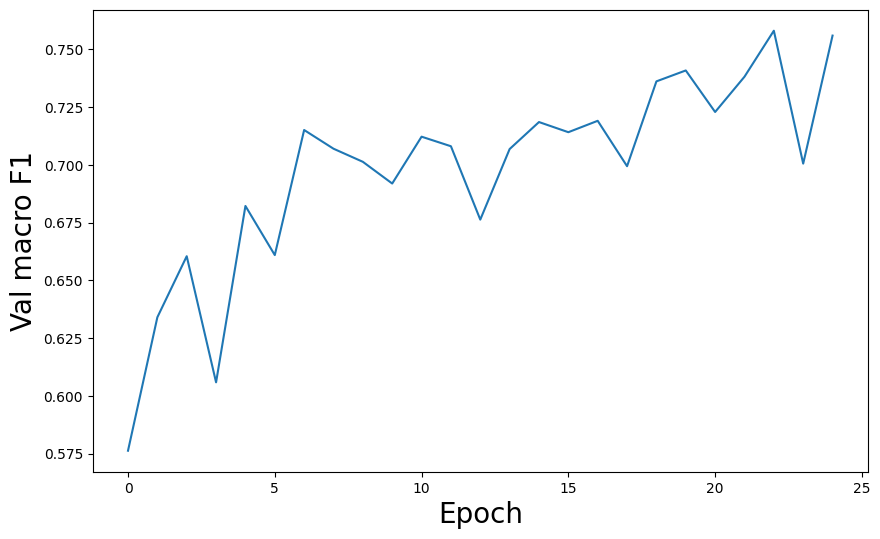

```python
trained_alexnet_pretrained, macro_f1_list_alexnet_pretrained = train_model(model, optimizer, criterion, device=device, num_epoch=25)
```

```python
models.efficientnet_v2_s(weights=None).classifier
```

```
Sequential(
  (0): Dropout(p=0.2, inplace=True)
  (1): Linear(in_features=1280, out_features=1000, bias=True)
)
```

```python
class EfficientNetV2(nn.Module):
    def __init__(self, num_classes):
        super().__init__()
        self.model = models.efficientnet_v2_s(weights=None)
        in_features = self.model.classifier[1].in_features
        self.model.classifier[1] = nn.Linear(in_features, num_classes)

    def forward(self, x):
        return self.model(x)
```

```python
model = EfficientNetV2(len(classes))
model.to(device)
optimizer = optim.Adam(model.parameters(), lr=0.0005)
```

```
Epoch:0, Loss:1.6250, Val macro F1: 0.2877
Epoch:1, Loss:1.4768, Val macro F1: 0.1761
Epoch:2, Loss:1.4008, Val macro F1: 0.2180
Epoch:3, Loss:1.2928, Val macro F1: 0.3735
Epoch:4, Loss:1.2337, Val macro F1: 0.4747
Epoch:5, Loss:1.1647, Val macro F1: 0.3550
Epoch:6, Loss:1.1418, Val macro F1: 0.2693
Epoch:7, Loss:1.0564, Val macro F1: 0.5540
Epoch:8, Loss:1.0126, Val macro F1: 0.5550
Epoch:9, Loss:0.9889, Val macro F1: 0.5524
Epoch:10, Loss:0.9626, Val macro F1: 0.5378
Epoch:11, Loss:0.9153, Val macro F1: 0.4402
Epoch:12, Loss:0.9010, Val macro F1: 0.4997
Epoch:13, Loss:0.8352, Val macro F1: 0.3745
Epoch:14, Loss:0.7962, Val macro F1: 0.4477
Epoch:15, Loss:0.7793, Val macro F1: 0.4028
Epoch:16, Loss:0.6961, Val macro F1: 0.4529
Epoch:17, Loss:0.7088, Val macro F1: 0.6607
Epoch:18, Loss:0.5906, Val macro F1: 0.5728
Epoch:19, Loss:0.5805, Val macro F1: 0.6265
Epoch:20, Loss:0.5746, Val macro F1: 0.6980
Epoch:21, Loss:0.5144, Val macro F1: 0.6666
Epoch:22, Loss:0.4978, Val macro F1: 0.7158
Epoch:23, Loss:0.4723, Val macro F1: 0.6741
Epoch:24, Loss:0.4122, Val macro F1: 0.6120
```

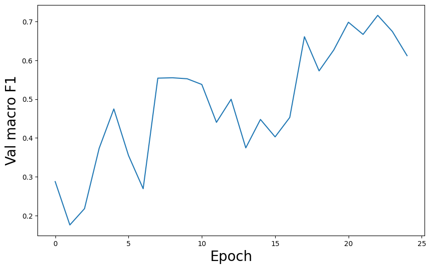

```python
trained_efficientnet_v2_s, macro_f1_list_efficientnet_v2_s = train_model(model, optimizer, criterion, device=device, num_epoch=25)
```

```python
class EfficientNetV2PreTrained(nn.Module):
    def __init__(self, num_classes):
        super().__init__()
        self.model = models.efficientnet_v2_s(weights=models.EfficientNet_V2_S_Weights.IMAGENET1K_V1)
        for param in self.model.parameters():
            param.requires_grad = False

        in_features = self.model.classifier[1].in_features
        self.model.classifier[1] = nn.Linear(in_features, num_classes)

    def forward(self, x):
        return self.model(x)
```

```python
model = EfficientNetV2PreTrained(len(classes))
model.to(device)
optimizer = optim.Adam(model.model.classifier[1].parameters(), lr=0.0005)
```

```
Downloading: "https://download.pytorch.org/models/efficientnet_v2_s-dd5fe13b.pth" to /root/.cache/torch/hub/checkpoints/efficientnet_v2_s-dd5fe13b.pth
```

```
Epoch:0, Loss:1.4417, Val macro F1: 0.5934
Epoch:1, Loss:1.0520, Val macro F1: 0.6396
Epoch:2, Loss:0.8933, Val macro F1: 0.6681
Epoch:3, Loss:0.7851, Val macro F1: 0.7237
Epoch:4, Loss:0.7156, Val macro F1: 0.7256
Epoch:5, Loss:0.6694, Val macro F1: 0.7351
Epoch:6, Loss:0.6470, Val macro F1: 0.7251
Epoch:7, Loss:0.6273, Val macro F1: 0.7369
Epoch:8, Loss:0.6094, Val macro F1: 0.7635
Epoch:9, Loss:0.5989, Val macro F1: 0.7540
Epoch:10, Loss:0.5701, Val macro F1: 0.7597
Epoch:11, Loss:0.5566, Val macro F1: 0.7480
Epoch:12, Loss:0.5571, Val macro F1: 0.7702
Epoch:13, Loss:0.5338, Val macro F1: 0.7615
Epoch:14, Loss:0.5042, Val macro F1: 0.7691
Epoch:15, Loss:0.5120, Val macro F1: 0.7803
Epoch:16, Loss:0.5129, Val macro F1: 0.7773
Epoch:17, Loss:0.4954, Val macro F1: 0.7622
Epoch:18, Loss:0.4959, Val macro F1: 0.7845
Epoch:19, Loss:0.4635, Val macro F1: 0.7990
Epoch:20, Loss:0.4636, Val macro F1: 0.7877
Epoch:21, Loss:0.4624, Val macro F1: 0.7957
Epoch:22, Loss:0.4663, Val macro F1: 0.7930
Epoch:23, Loss:0.4773, Val macro F1: 0.7980
Epoch:24, Loss:0.4486, Val macro F1: 0.7782
```

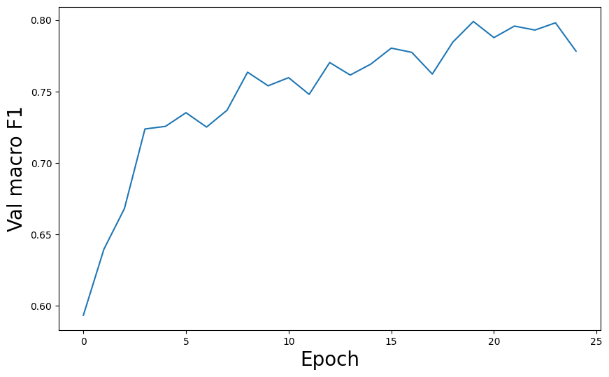

```python
trained_efficientnet_v2_s_pretrained, macro_f1_list_efficientnet_v2_s_pretrained = train_model(model, optimizer, criterion, device=device, num_epoch=25)
```

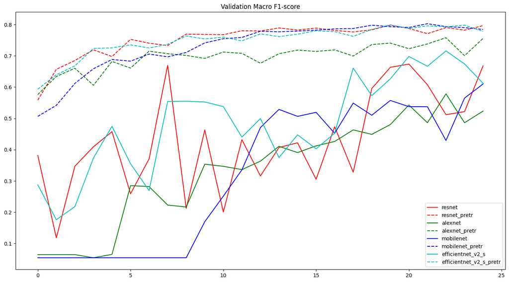

```python
x = np.arange(0, 25)
fig, ax = plt.subplots(figsize=(17, 9))
ax.plot(x, macro_f1_list_resnet, label="resnet", c="r")
ax.plot(x, macro_f1_list_resnet_pretrain, label="resnet_pretr", c="r", linestyle='dashed')
ax.plot(x, macro_f1_list_alexnet, label="alexnet", c="g")
ax.plot(x, macro_f1_list_alexnet_pretrained, label="alexnet_pretr", c="g", linestyle='dashed')
ax.plot(x, macro_f1_list_mobilenet, label="mobilenet", c="b")
ax.plot(x, macro_f1_list_mobilenet_pretrain, label="mobilenet_pretr", c="b", linestyle='dashed')
ax.plot(x, macro_f1_list_efficientnet_v2_s, label="efficientnet_v2_s", c="c")
ax.plot(x, macro_f1_list_efficientnet_v2_s_pretrained, label="efficientnet_v2_s_pretr", c="c", linestyle='dashed')
ax.set_title("Validation Macro F1-score")
ax.legend()
```

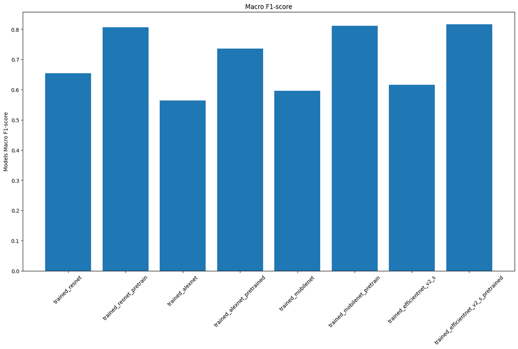

```python
models = [
    trained_resnet, trained_resnet_pretrain, trained_alexnet,
    trained_alexnet_pretrained, trained_mobilenet, trained_mobilenet_pretrain,
    trained_efficientnet_v2_s, trained_efficientnet_v2_s_pretrained,
]
name_models = [
    "trained_resnet", "trained_resnet_pretrain", "trained_alexnet",
    "trained_alexnet_pretrained", "trained_mobilenet", "trained_mobilenet_pretrain",
    "trained_efficientnet_v2_s", "trained_efficientnet_v2_s_pretrained",
]

f1_scores = []

for model in models:
    f1_val = model_validate(model, test_loader, device)
    f1_scores.append(f1_val)

fig, ax = plt.subplots(figsize=(17, 9))

ax.bar(name_models, f1_scores)
ax.set_ylabel('Models Macro F1-score')
ax.set_title('Macro F1-score')
ax.tick_params(axis='x', labelrotation=45)

plt.show()
```

```python
f1_scores
```

```
[0.6543450079039417,
 0.8068087840527635,
 0.5637873580472419,
 0.7364490031609753,
 0.5961626316471421,
 0.8115116870994541,
 0.6155507742672334,
 0.8171278244952401]
```

```python
name_models[np.argmax(f1_scores)]
```

```
'trained_efficientnet_v2_s_pretrained'
```